Service de l'Habitation, Division Stratégies et Politiques

# Portrait de l'Habitation

## Profil des ménages et des logements

### Ville de Montréal

- Cartographie du territoire
- Nombre de ménages privés
- Composition des ménages
- Ménages avec enfants
- Groupes d'âges
- Ménages immigrants et résidents non permanents
- Ménages étudiants
- Revenus
- Frais de logement
- Taux d'effort
- Surpeuplement
- État d'entretien
- Parc de logement

Élaboré à partir de données personnalisées du recensement de 2021 de Statistique Canada, ce profil des ménages et des logements couvre les principales dimensions liées à l’habitation dans le but de mieux comprendre les enjeux et préoccupations locales. Des tableaux et faits saillants facilitent les analyses pour le territoire de la Ville de Montréal et les arrondissements qui la composent.

**Instructions d'utilisation :** Les données peuvent être triées par ordre croissant ou décroissant en appuyant sur les en-têtes de colonnes. Le bouton *Télécharger le tableau* offre la possibilité d’exporter les données au format Excel. Des boutons de ventilation permettent de filtrer les données selon les paramètres disponibles. La ventilation par genre (Homme+ ou Femme+) renvoie au genre du principal soutien du ménage (PSM). La ventilation du mode d'occupation (Propriétaires ou Locataires) précise si le ménage est propriétaire ou locataire de son logement.

L'ensemble des définitions contenues dans le rapport sont basées sur le [Dictionnaire, Recensement de la population, 2021](https://www12.statcan.gc.ca/census-recensement/2021/ref/dict/index-fra.cfm). Toutes les données présentées ont été arrondies aléatoirement à un multiple de 5, ce qui peut entraîner des écarts entre leur somme et les totaux affichés.

# Le ménage privé désigne une personne ou un groupe de personnes qui occupent le même logement privé et qui n’ont pas de domicile habituel ailleurs au Canada ou à l’étranger. **Principal soutien du ménage (PSM)** : le PSM (Homme+ ou Femme+) est la première personne désignée dans un ménage comme effectuant le paiement du loyer, de l’hypothèque ou des taxes associées au logement. Dans le cas d’un ménage où deux personnes ou plus sont inscrites comme soutiens du ménage, le PSM est déterminé par l’ordre dans lequel les personnes sont inscrites dans le questionnaire et ne correspond pas nécessairement à la proportion des paiements du ménage effectués par la personne. **Femme+/Homme+** : dans le Recensement de 2016, cette catégorie fait référence au sexe féminin/masculin. À compter de 2021, cette catégorie comprend les hommes/femmes (et/ou les filles/les garçons) de même que certaines personnes non binaires. Statistique Canada indique que, étant donné la petite taille de la population non binaire, il est parfois nécessaire d’agréger les données dans une variable de genre à deux catégories pour protéger la confidentialité des réponses fournies. Dans ces cas, les personnes de la catégorie « personnes non binaires » sont réparties dans les deux autres catégories de genre et sont désignées par le signe +. Pour obtenir de plus amples renseignements sur les changements dans les concepts au fil du temps, veuillez consulter le [Guide de référence sur l’âge, le sexe à la naissance et le genre de Statistique Canada](https://www12.statcan.gc.ca/census-recensement/2021/ref/98-500/014/98-500-x2021014-fra.cfm). En 2021, la Ville de Montréal recense **816 355** ménages, soit une **hausse** de **4,7 %** par rapport à 2016. **Ville-Marie** est l'arrondissement ayant enregistré la plus forte croissance entre 2016 et 2021, soit une hausse de **19,4 %** des ménages. **Le Sud-Ouest** se trouve au deuxième rang, avec une hausse de **10,5 %** de ses ménages. Entre 2016 et 2021, la proportion de ménages **locataires** dans la ville est passée de **63,3 %** à **63,6 %** (soit une augmentation de **0,3** points de pourcentage). La proportion de ménages **propriétaires** dans la ville est passée de **36,7 %** à **36,4 %** (soit une diminution de **0,3** points de pourcentage). Les ménages peuvent être répartis en deux grandes catégories : ceux comprenant au moins une famille de recensement et ceux n’en comprenant aucune. Les premiers regroupent les couples sans enfants, les couples avec enfants, les familles monoparentales ainsi que les ménages multifamiliaux. Les ménages sans famille de recensement, quant à eux, sont constitués soit d’une personne vivant seule, soit d’un groupe de deux personnes ou plus partageant un logement sans former une famille de recensement — comme c’est le cas, par exemple, des colocataires. * La catégorie « Autres » comprend les ménages multifamiliaux et les ménages non familiaux de deux personnes et plus, tel que les colocations. En 2021, les **personnes seules** constituent le type de ménage le plus important, représentant **41,8 %** de l'ensemble des ménages de la Ville de Montréal. Les ménages de cette catégorie sont principalement **locataires** (à **74,4 %**). La proportion de familles monoparentales correspond à **10,4 %** des ménages de la Ville de Montréal. La plus grande proportion de ménages monoparentaux se trouve dans l'arrondissement de **Montréal-Nord** (**17,5 %**). Les couples sans enfants et les couples avec enfants sont plus fréquemment **propriétaires** de leur logement que l'ensemble des ménages. En effet, **50,0 %** des couples sans enfants et **53,7 %** des couples avec enfants sont propriétaires. En revanche, on constate que les familles monoparentales, les personnes seules, les ménages « Autres » sont majoritairement **locataires**, avec des taux de **68,0 %**, **74,4 %**, **81,4 %** respectivement. Pour être inclus dans cette catégorie, les enfants doivent être âgés de moins de 18 ans et vivre dans le même ménage que la famille, ils peuvent être des enfants biologiques ou adoptés. Sont considérées comme chambres à coucher les pièces d’un logement conçues pour y dormir, même si elles sont utilisées à d’autres fins. La Ville de Montréal compte **178 765** ménages avec enfant(s) en 2021, constituant **21,9 %** de l'ensemble des ménages. Les arrondissements présentant la plus forte proportion de ménages avec enfant(s) sont **Saint-Laurent** (**31,9 %**) et **Outremont** (**31,7 %**). Parmi les ménages avec enfants, **56,7 %** sont **locataires**, tandis que **43,3 %** sont **propriétaires**. Alors que **77,1 %** des ménages propriétaires avec enfants occupent un logement de 3 chambres à coucher et plus, **38,9 %** des locataires occupent des logements de 3 chambres à coucher et plus. Près de **6,7 %** des ménages avec enfants résident dans un studio ou un logement d'une chambre, ce qui ne répond pas à la Norme nationale d’occupation (NNO) en matière de taille convenable. Cette proportion est particulièrement présente dans les arrondissements de **Ville-Marie** (**16,4 %**) et de **Côte-des-Neiges-Notre-Dame-de-Grâce** (**15,5 %**). Les groupes d’âges sont ceux du principal soutien du ménage (PSM). Le groupe d'âge le plus fréquent est celui des 35 à 44 ans, avec une proportion de **19,2 %** des ménages. La proportion de ménages dont le PSM est âgé de moins de 35 ans est particulièrement importante dans **Ville-Marie** (**43,5 %**) et dans **Plateau-Mont-Royal** (**39,3 %**). La proportion de ménages dont le PSM est âgé de **65 ans ou plus** est la plus importante à **Anjou** représentant **32,5 %** des ménages, suivi par **Saint-Léonard** avec **31,7 %** des ménages. Dans la Ville de Montréal, le groupe d'âge le plus fréquent chez les **propriétaires** est celui des **55 à 64 ans** (**21,2 %**). Chez les **locataires**, ce sont les ménages dont le PSM est âgé de **25 à 34 ans** qui sont les plus nombreux (**24,2 %**). Le statut d’immigrant indique si le principal soutien du ménage est un immigrant ou un résident non permanent. Un immigrant désigne une personne à qui les autorités de l’immigration ont accordé le droit de résider au Canada en permanence. Les immigrants qui ont obtenu la citoyenneté canadienne par naturalisation sont compris dans ce groupe. Un résident non permanent désigne une personne originaire d’un autre pays dont le lieu de résidence habituel est le Canada et qui est titulaire d’un permis de travail ou d’études ou qui a demandé le statut de réfugié. * La catégorie « Autres » comprend les ménages multifamiliaux et les ménages non familiaux de deux personnes et plus, tel que les colocations. La Ville de Montréal compte **367 165 ménages immigrants ou résidents non permanents**, représentant **45,0 %** de la population. Parmi ces ménages, **83,3 %** sont des ménages immigrants et **16,7 %** sont des ménages résidents non permanents. La plus forte proportion de ménages immigrants se trouve dans **Saint-Laurent** où ils représentent **63,6 %** de l'ensemble des ménages, suivi par **Saint-Léonard** avec **59,9 %** de l'ensemble des ménages. Dans la Ville de Montréal, **38,6 %** des ménages immigrants sont propriétaires de leur logement, comparativement à **36,4 %** pour l'ensemble des ménages. Les **personnes seules** constituent le type de ménage le plus fréquent, représentant **32,6 %** de l'ensemble des ménages immigrants de la ville. Les résidents non permanents sont majoritairement des **personnes seules** (**39,4 %** des résidents non permanents). Les ménages étudiants sont composés de ménages non-familiaux et de personnes seules et sont occupés par au moins un étudiant, à temps plein ou à temps partiel, de 15 ans et plus. Les étudiants à l’école primaire, intermédiaire et secondaire sont exclus. La Ville de Montréal compte **63 135 ménages étudiants** (**7,7 %** de tous les ménages). Les arrondissements avec les plus fortes concentrations d'étudiants sont **Ville-Marie** (**17,8 %**), **Plateau-Mont-Royal** (**15,8 %**) et **Côte-des-Neiges-Notre-Dame-de-Grâce** (**12,1 %**). Les arrondissements avec les plus faibles proportions de ménages étudiants sont **Île-Bizard-Sainte-Geneviève** (**1,4 %**), **Pierrefonds-Roxboro** (**1,6 %**) et **Rivière-des-Prairies-Pointe-aux-Trembles** (**1,6 %**). Les ménages étudiants de la Ville de Montréal sont majoritairement **locataires** (**88,9 %**), tandis que **11,1 %** sont propriétaires. Les revenus sont les revenus du ménage pour l’année civile 2020, avant impôts. Le revenu médian est la valeur qui sépare les ménages en deux groupes égaux, la moitié des ménages ayant un revenu supérieur à la médiane et l’autre moitié ayant un revenu inférieur. Note : L’année 2020 a été marquée par la mise en œuvre de plusieurs programmes gouvernementaux de soutien du revenu en réponse aux répercussions économiques de la pandémie de COVID-19. Certains de ces transferts gouvernementaux étaient ponctuels et ont pu modifier temporairement la situation financière des ménages bénéficiaires. Il est donc suggéré d’interpréter ces données avec prudence. Le revenu médian des ménages de la Ville de Montréal est de **63 600 $**. L'arrondissement où le revenu médian est le plus bas est **Ville-Marie** avec **53 600 $** et celui où le revenu médian est le plus élevé est **Outremont** avec **101 000 $**. Le revenu médian des ménages propriétaires (**98 000 $**) est **nettement supérieur** à celui des ménages locataires (**50 800 $**). Le revenu médian des ménages dont le PSM est une femme+ s'élève à **58 400 $**, contre **69 000 $** lorsque le PSM est un homme+, soit un écart de **18,2 %**. Montant total des frais de logement payés mensuellement par les ménages. Chez les propriétaires, cela comprend, s’il y a lieu, les paiements hypothécaires, l’impôt foncier et les charges de copropriété, ainsi que les frais d’électricité, de chauffage, d’eau et des autres services municipaux. Pour les ménages locataires, cela comprend le loyer, les frais d’électricité, de chauffage, d’eau et des autres services municipaux. Note : L’indication **nd** signifie que les données ne sont pas disponibles dans la commande personnalisée du Recensement auprès de Statistique Canada. Cette indisponibilité découle notamment de l’application des dispositions de confidentialité prévues par la *Loi sur la statistique*, lorsque le faible nombre de ménages concernés pourrait permettre l’identification d’individus ou de logements. L’indication **na** signifie que les données sont non applicables, par exemple lorsqu’aucun ménage propriétaire de studio (sans chambre à coucher) n’est recensé sur le territoire. Le calcul de la variation entre 2016 et 2021 ne prend pas en compte l’inflation. **1. Frais de logement selon la composition du ménage** **2. Frais de logement selon le nombre de chambres** Les frais de logement médians sont passés de **832 $** en 2016 à **950 $** en 2021, soit une augmentation de **14,2 %**. Les frais de logement médians des propriétaires (**1 360 $**) ont augmenté de **12,7 %**, tandis que ceux des locataires (**870 $**) ont augmenté de **13,0 %**. Les frais de logement médians les plus élevés se trouvent à **Outremont**, avec **1 500 $**. **Ville-Marie** est l'arrondissement ayant connu la plus forte augmentation (+**26,1 %**) des frais de logement médians entre 2016 et 2021, passant de 983 $ à 1 240 $. Le taux d’effort correspond à la proportion du revenu annuel brut qu’un ménage consacre à ses frais de logement, incluant les frais de location ou d’hypothèque, les taxes et les frais de chauffage et d’électricité. Les ménages dont le revenu total est égal à zéro ou négatif sont exclus. Note : L’année 2020 a été marquée par la mise en œuvre de plusieurs programmes gouvernementaux de soutien du revenu en réponse aux répercussions économiques de la pandémie de COVID-19. Certains de ces transferts gouvernementaux étaient ponctuels et ont pu modifier temporairement la situation financière des ménages bénéficiaires. Il est donc suggéré d’interpréter ces données avec prudence. * La catégorie « Autres » comprend les ménages multifamiliaux et les ménages non familiaux de deux personnes et plus, tel que les colocations. À Montréal, **24 %** des ménages consacrent 30 % ou plus de leur revenu aux frais de logement. La proportion de ménages consacrant 50 % ou plus de leur revenu aux frais de logement s'élevait à **9,3 %**. Parmi les arrondissements, la proportion des ménages ayant un taux d'effort de 30 % et plus varie de **16,1 %** à **Rivière-des-Prairies-Pointe-aux-Trembles** à **37,2 %** à **Ville-Marie**. Dans l'arrondissement de Ville-Marie, près de **21,3 %** des ménages locataires ont un taux d'effort de 50 % et plus. Les **personnes seules** présentent le taux d'effort le plus élevé, avec **37,1 %** des ménages consacrant 30 % ou plus de leur revenu au logement et **15,3 %** des ménages consacrant 50 % ou plus de leur revenu aux frais de logement. Parmi les ménages **propriétaires**, **17,9 %** consacrent 30 % ou plus de leur revenu au logement, contre **27,5 %** des ménages **locataires**. La taille convenable du logement indique si un ménage privé vit dans des locaux de taille convenable selon la Norme nationale d’occupation (NNO), à savoir si le logement comporte suffisamment de chambres à coucher pour la taille et la composition du ménage. Les personnes seules ne peuvent pas avoir de logement de taille non convenable selon la Norme nationale d’occupation (NNO), cette catégorie est alors retirée du tableau. Note : La colonne *Variation 2016-2021 (%)* indique l’évolution de la proportion de logements de taille insuffisante entre 2016 et 2021, exprimée en points de pourcentage. * La catégorie « Autres » comprend les ménages multifamiliaux et les ménages non familiaux de deux personnes et plus, tel que les colocations. On dénombre **70 450 logements** de taille insuffisante dans la Ville de Montréal, représentant **8,6%** de l'ensemble des logements occupés. La catégorie **Autres** (ménages multifamiliaux et ménages non familiaux de deux personnes et plus) enregistre le taux le plus élevé de surpeuplement, avec **25,9%** de logements de taille insuffisante. L'arrondissement de **Saint-Laurent** présente le taux de surpeuplement le plus élevé de la Ville de Montréal, avec **14,9%** de logements de taille insuffisante, suivi de **Côte-des-Neiges-Notre-Dame-de-Grâce** avec **13,9%**. Le taux de surpeuplement est de **4,3%** chez les propriétaires contre **11,1%** chez les locataires. Chez les ménages locataires, le taux de surpeuplement le plus élevé se trouve dans l'arrondissement de **Saint-Laurent**, avec **23,5%** des logements de taille insuffisante. L’état d’entretien indique si, selon l’occupant, le logement nécessite des réparations. Cette notion ne comprend pas les rénovations désirées ni les ajouts. Les *réparations mineures* sont nécessaires dans les cas suivants : carreaux de plancher détachés ou manquants, briques descellées, bardeaux arrachés, marches, rampes ou revêtement extérieur défectueux, etc. Les *réparations majeures* doivent être effectuées lorsque la plomberie ou l’installation électrique est défectueuse, que la charpente des murs, des planchers ou des plafonds doit être réparée, etc. En 2021, on dénombre **224 335 logements** (**27,5%**) nécessitant des réparations mineures et **70 075 logements** (**8,6%**) nécessitant des réparations majeures. Entre 2016 et 2021, le nombre de logements nécessitant des réparations mineures a **augmenté** de **3,6%**, le nombre de ceux nécessitant des réparations majeures a **augmenté** de **12,4%**. L'arrondissement du **Plateau-Mont-Royal** présente la plus forte proportion de logements nécessitant des réparations majeures avec **10,9%** des logements occupés. Entre 2016 et 2021, **Anjou** a connu la plus forte hausse du nombre de logements nécessitant des réparations majeures, avec une augmentation de **39,2%**. Le type de bâtiments réfère au type de construction et/ou aux caractéristiques des logements occupés, excluant ainsi les logements vacants. Les *maisons unifamiliales* comprennent les maisons individuelles, les maisons jumelées ainsi que les maisons en rangée. Les *appartements* sont répartis en deux catégories : les duplex ou immeubles de moins de cinq étages, et les immeubles comptant cinq étages ou plus. Les **702 315** appartements (tous types confondus) de la ville représentent **86,0 %** de l'ensemble des logements occupés. Les maisons unifamiliales représentent **13,9%** du parc de la Ville de Montréal. Les **appartements dans un duplex/immeuble de moins de 5 étages** représentent la plus grande part du parc avec **70,0%** des logements occupés.

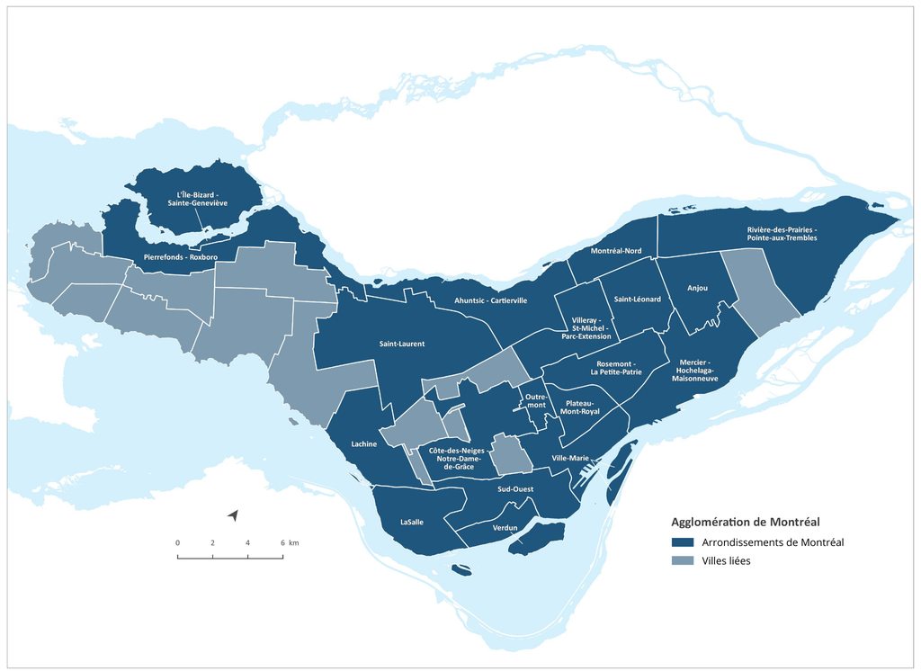

[interactive chart not shown]